# USArrest_PCA_example

10/10/2019

## PCA Example on US Arrest data

This is making use of a built in example data set USArrests

```r
data(USArrests)
head(USArrests)
```

```
##            Murder Assault UrbanPop Rape
## Alabama      13.2     236       58 21.2
## Alaska       10.0     263       48 44.5
## Arizona       8.1     294       80 31.0
## Arkansas      8.8     190       50 19.5
## California    9.0     276       91 40.6
## Colorado      7.9     204       78 38.7
```

We we will scale or standardize the data. In scaling, we subtract the mean and divide by the standard deviation so the variables all have mean of zero and stddeve=1

This is done because of the wide variation in the scale of measurement

```r
scArrests=apply(USArrests,2,scale)
mean(scArrests)
```

```
## [1] -7.739713e-17
```

```r
sd(scArrests)
```

```
## [1] 0.9924337
```

```r
head(scArrests)
```

```
##          Murder   Assault   UrbanPop         Rape
## [1,] 1.24256408 0.7828393 -0.5209066 -0.003416473
## [2,] 0.50786248 1.1068225 -1.2117642  2.484202941
## [3,] 0.07163341 1.4788032  0.9989801  1.042878388
## [4,] 0.23234938 0.2308680 -1.0735927 -0.184916602
## [5,] 0.27826823 1.2628144  1.7589234  2.067820292
## [6,] 0.02571456 0.3988593  0.8608085  1.864967207
```

Note that the var-cov matrix of the scaled data is actually now a correlation matrix

We can now run the PCA

```r
z2=prcomp(USArrests,scale=TRUE)
summary(z2)
```

```
## Importance of components:
##                           PC1    PC2     PC3     PC4
## Standard deviation     1.5749 0.9949 0.59713 0.41645
## Proportion of Variance 0.6201 0.2474 0.08914 0.04336
## Cumulative Proportion  0.6201 0.8675 0.95664 1.00000
```

Let’s plot the first two PCA axes scores

```r
require(ggplot2)
State<-rownames(USArrests)
PC1=z2$x[,1]
PC2=z2$x[,2]
PC3=z2$x[,3]
PC4=z2$x[,4]
myScores=data.frame(PC1=PC1,PC2=PC2,PC3=PC3,PC4=PC4)

#quartz()
#windows()
```

```r
print(z2$rotation)
```

```
##                 PC1        PC2        PC3         PC4
## Murder   -0.5358995  0.4181809 -0.3412327  0.64922780
## Assault  -0.5831836  0.1879856 -0.2681484 -0.74340748
## UrbanPop -0.2781909 -0.8728062 -0.3780158  0.13387773
## Rape     -0.5434321 -0.1673186  0.8177779  0.08902432
```

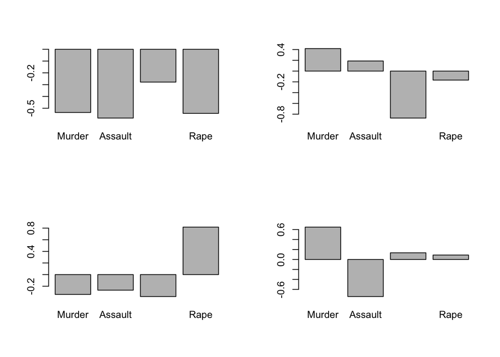

```r
par(mfrow=c(2,2))
barplot(z2$rotation[,1])
barplot(z2$rotation[,2])
barplot(z2$rotation[,3])
barplot(z2$rotation[,4])
```

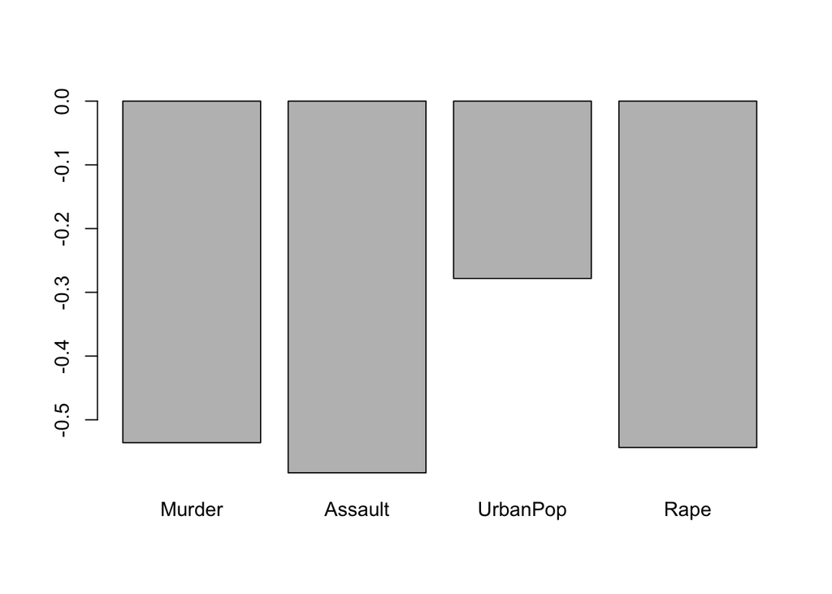

```r
barplot(z2$rotation[,1])
```

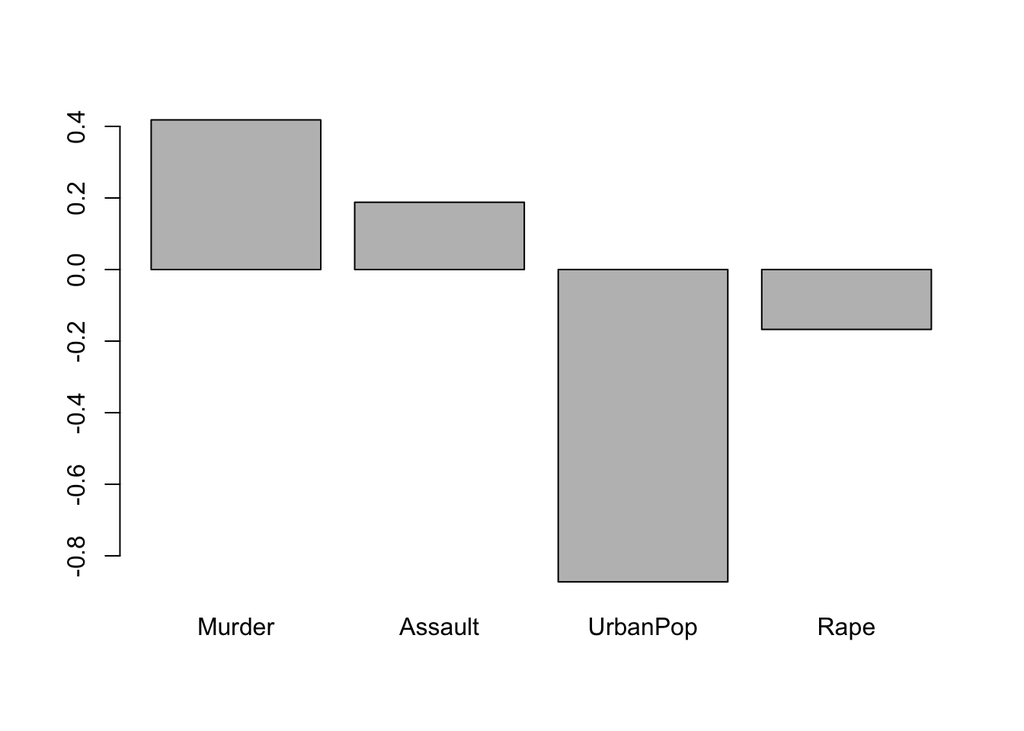

```r
barplot(z2$rotation[,2])
```

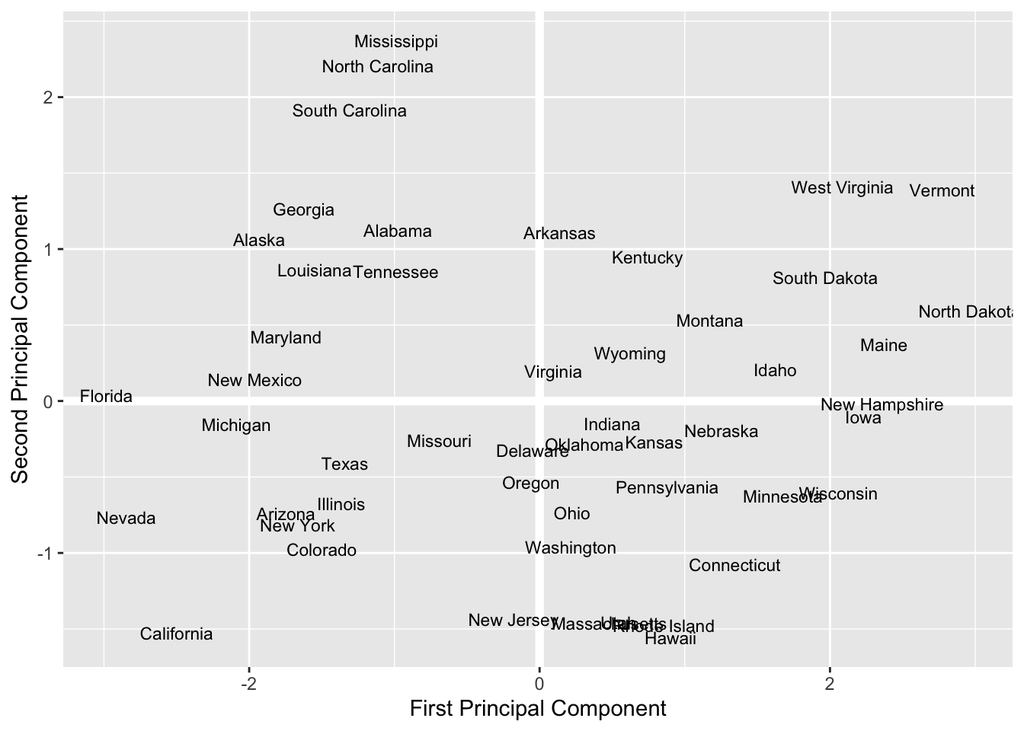

```r
p<-ggplot(myScores, aes(PC1,PC2)) +
  modelr::geom_ref_line(h = 0) +
  modelr::geom_ref_line(v = 0) +
   geom_text(aes(label = State), size = 3) +
  xlab("First Principal Component") +
  ylab("Second Principal Component")

print(p)
```

x axis: murder,assault,rape; high left/low right y axis: urban population; high bottom/low top

Top right: low urban population, low murder,assault,rape Bottom right: high urban population, low murder,assauly,rape Bottom left: high urban population, high murder,assault,rape Top left: low urban population, high murder,assault,rape

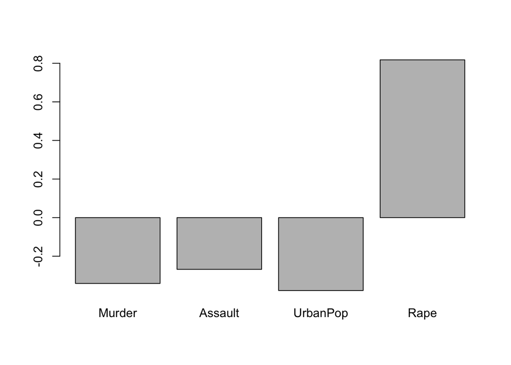

```r
barplot(z2$rotation[,3])
```

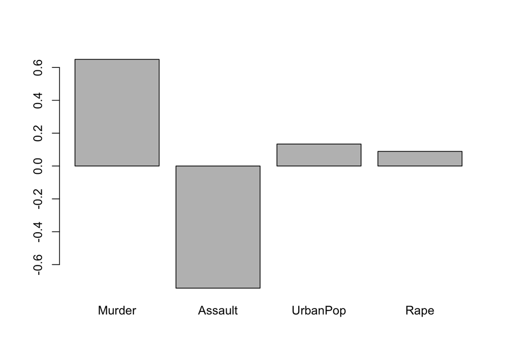

```r
barplot(z2$rotation[,4])
```

Looking at cumulative varience explained PC1 and PC2 are the most.

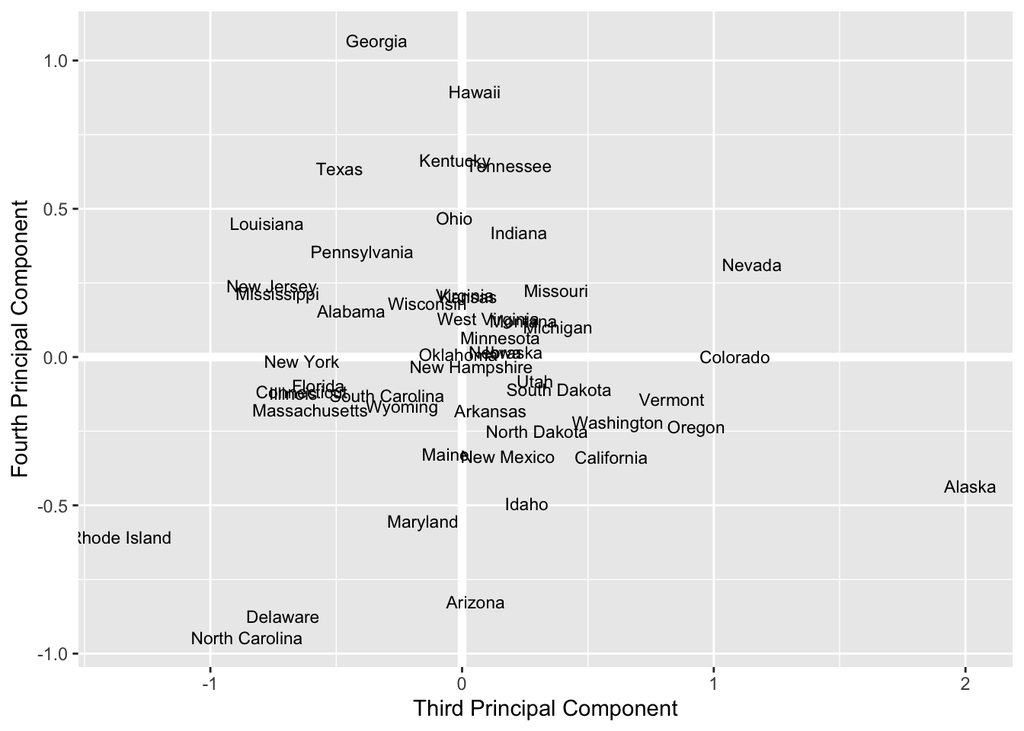

```r
p<-ggplot(myScores, aes(PC3,PC4)) +
  modelr::geom_ref_line(h = 0) +
  modelr::geom_ref_line(v = 0) +
   geom_text(aes(label = State), size = 3) +
  xlab("Third Principal Component") +
  ylab("Fourth Principal Component")

print(p)
```

x axis: rape; low left/high right y axis: Murder,Assault; low murder;high assault;bottom/high murder;low assault;top

Top right: high rape/high murder;low assault Bottom right: high rape/low murder;high assault Bottom left: low rape/low murder;high assault Top left: low rape/high murder;low assault

```r
pr.out=prcomp(USArrests,scale=TRUE)
pr.out$rotation
```

```
##                 PC1        PC2        PC3         PC4
## Murder   -0.5358995  0.4181809 -0.3412327  0.64922780
## Assault  -0.5831836  0.1879856 -0.2681484 -0.74340748
## UrbanPop -0.2781909 -0.8728062 -0.3780158  0.13387773
## Rape     -0.5434321 -0.1673186  0.8177779  0.08902432
```

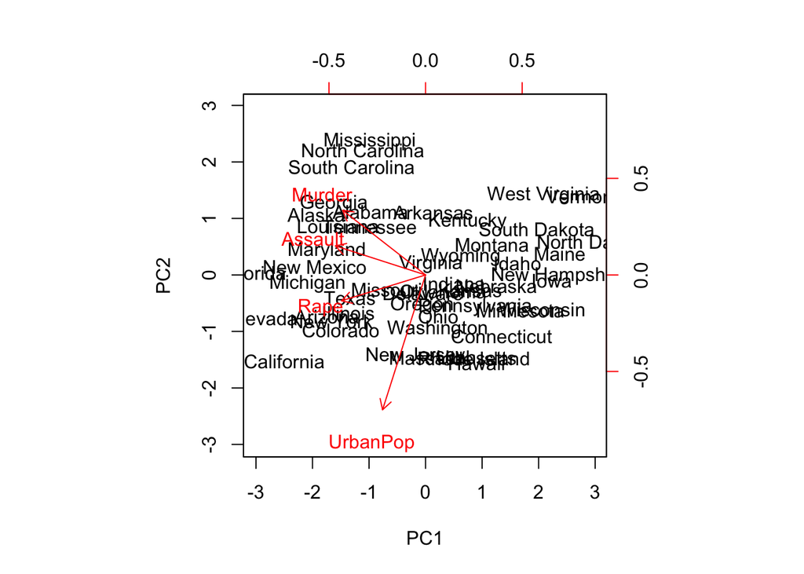

```r
biplot(pr.out, scale=0)
```

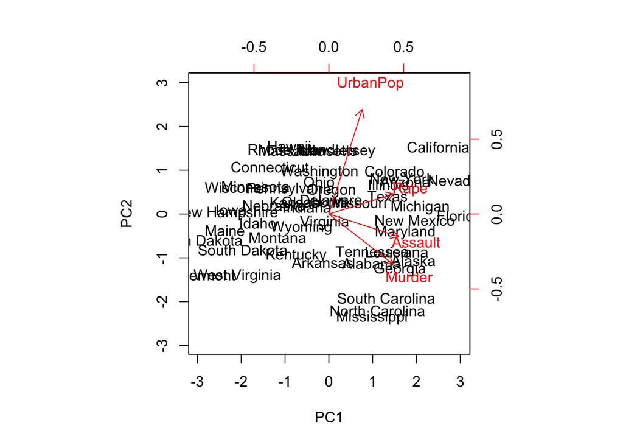

```r
pr.out$rotation=-pr.out$rotation
pr.out$x=-pr.out$x
plot1 <- biplot(pr.out,scale=0)
```

```r
plot1
```

```r
# 1. Open jpeg file
jpeg("biplot_PCA_USArrests.jpg", width = 900, height = 900)
# 2. Create the plot
biplot(pr.out,scale=0)
# 3. Close the file
dev.off()
```